# Exploring Yelp Reviews

In this project, I'll explore restaurant review data available through the [Yelp Dataset Challenge](https://www.yelp.com/dataset/challenge). The dataset includes Yelp data for user reviews and business information for 10 metropolitan areas. Cleveland were chosen since the data is not too large — the data for the other cities can be downloaded from the Yelp download page.

#### Part 1: testing how well sentiment analysis works.

Because Yelp reviews include the number of stars given by the user, the Yelp data set provides a unique opportunity to test how well the sentiment analysis works by comparing the number of stars to the polarity of reviews.

#### Part 2: analyzing correlations between restaurant reviews and census data

I'll explore geographic trends in the restaurant reviews, comparing our sentiment analysis results with user stars geographically. We'll also overlay review stars on maps of household income (using census data).

#### Background

- [Does sentiment analysis work?](http://varianceexplained.org/r/yelp-sentiment/)
- [The Geography of Taste: Using Yelp to Study Urban Culture](https://www.mdpi.com/2220-9964/7/9/376/pdf/1)

## 1. Does Sentiment Analysis Work?

### 1.1 Load review data

```python
# importing packages to use
import pandas as pd
```

```python
# Load review data
review_data=pd.read_json("./data/reviews_cleveland.json.gz",orient='records',lines=True)
```

```python
review_data.head()
```

|  | business_id | review_id | stars | text |
| --- | --- | --- | --- | --- |
| 0 | ZNB91myFoOYgyXoG5LQeGQ | 36xxeOr4m4UlRf9FM1HzdA | 1 | I took my wife out for a Birthday dinner with ... |
| 1 | anzCdD5eIEHwydTpXhLlUA | 4PKiLkFTff9HK44QkOo6vA | 4 | Heard about this place and was dying to check ... |
| 2 | CtYWpX_cy1YdZgoKtS0Tqg | ydehlths0Zpg2gbXPOs6Qw | 1 | Also don't believe when they say they will giv... |
| 3 | QUjJmpTQvGus8WfYq1dtOw | 3WAN3SLDZZhcKGazQOdzGg | 1 | Quite possibly the worst meal I have had in ag... |
| 4 | m3DVIvPsuLuA9OMSgWNLcQ | G_4LjxpwN1FAmR0056Ux1w | 4 | Delicious oatmeal raisin cookie. Cute little s... |

### 1.2 Format the review text

The first step is to split the review text into its individual words and make all of the words lower-cased.

Add a new column, called 'formatted_text', which each entry is a list of the lower-cased words in a review.

```python
# lower-cased split text
review_data["formatted_text"] = review_data.text.str.lower().str.split()
```

```python
review_data.head()
```

|  | business_id | review_id | stars | text | formatted_text |
| --- | --- | --- | --- | --- | --- |
| 0 | ZNB91myFoOYgyXoG5LQeGQ | 36xxeOr4m4UlRf9FM1HzdA | 1 | I took my wife out for a Birthday dinner with ... | [i, took, my, wife, out, for, a, birthday, din... |
| 1 | anzCdD5eIEHwydTpXhLlUA | 4PKiLkFTff9HK44QkOo6vA | 4 | Heard about this place and was dying to check ... | [heard, about, this, place, and, was, dying, t... |
| 2 | CtYWpX_cy1YdZgoKtS0Tqg | ydehlths0Zpg2gbXPOs6Qw | 1 | Also don't believe when they say they will giv... | [also, don't, believe, when, they, say, they, ... |
| 3 | QUjJmpTQvGus8WfYq1dtOw | 3WAN3SLDZZhcKGazQOdzGg | 1 | Quite possibly the worst meal I have had in ag... | [quite, possibly, the, worst, meal, i, have, h... |
| 4 | m3DVIvPsuLuA9OMSgWNLcQ | G_4LjxpwN1FAmR0056Ux1w | 4 | Delicious oatmeal raisin cookie. Cute little s... | [delicious, oatmeal, raisin, cookie., cute, li... |

### 1.3 Review stop words

`nltk` library is used to remove any stop words from the list of words in each review.

Overwrites the 'formatted_text' column to contain a list of lower-cased words in each review, with no stop words.

```python
import nltk
import re

# load stop words
nltk.download('stopwords')
stop_words = list(set(nltk.corpus.stopwords.words('english')))
```

```python
def remove_punctuation(word):
    # using re to remove the punctuation
    # instead of the string package to deal with
    # words like "example." or "(another" and make them
    # "example" or "another"
    return re.sub(r"[^\w]","",word)

def remove_stop_words_and_punctuation(word_list):
    # remove stop words and punctuations in the word list
    word_list_return = []
    for word in word_list:
        word_remove = remove_punctuation(word)
        # if word is null, pass this
        if not word_remove: continue
        if word_remove not in stop_words:
            word_list_return.append(word_remove)
    return word_list_return
```

```python
# apply the func
review_data.formatted_text = review_data.formatted_text.apply(remove_stop_words_and_punctuation)
```

### 1.4 Calculate polarity and subjectivity

Using the formatted text column, create a list of `textblob.TextBlob()` objects and then extract the `subjectivity` and `polarity`.

Add two new columns to the review DataFrame: `polarity` and `subjectivity`.

```python
import textblob
```

```python
blobs = [textblob.TextBlob(" ".join(t)) for t in review_data.formatted_text]
```

```python
review_data["polarity"] = [b.polarity for b in blobs]
review_data["subjectivity"] = [b.subjectivity for b in blobs]
```

```python
review_data.head()
```

|  | business_id | review_id | stars | text | formatted_text | polarity | subjectivity |
| --- | --- | --- | --- | --- | --- | --- | --- |
| 0 | ZNB91myFoOYgyXoG5LQeGQ | 36xxeOr4m4UlRf9FM1HzdA | 1 | I took my wife out for a Birthday dinner with ... | [took, wife, birthday, dinner, daughter, 12161... | 0.117949 | 0.476923 |
| 1 | anzCdD5eIEHwydTpXhLlUA | 4PKiLkFTff9HK44QkOo6vA | 4 | Heard about this place and was dying to check ... | [heard, place, dying, check, putand, im, glad,... | 0.299366 | 0.686480 |
| 2 | CtYWpX_cy1YdZgoKtS0Tqg | ydehlths0Zpg2gbXPOs6Qw | 1 | Also don't believe when they say they will giv... | [also, dont, believe, say, give, credit, unsat... | 0.000000 | 0.000000 |
| 3 | QUjJmpTQvGus8WfYq1dtOw | 3WAN3SLDZZhcKGazQOdzGg | 1 | Quite possibly the worst meal I have had in ag... | [quite, possibly, worst, meal, ages, service, ... | -0.237500 | 0.543590 |
| 4 | m3DVIvPsuLuA9OMSgWNLcQ | G_4LjxpwN1FAmR0056Ux1w | 4 | Delicious oatmeal raisin cookie. Cute little s... | [delicious, oatmeal, raisin, cookie, cute, lit... | 0.345000 | 0.800000 |

### 1.5 Comparing the sentiment analysis to number of stars

```python
import seaborn as sns
import matplotlib.pyplot as plt
```

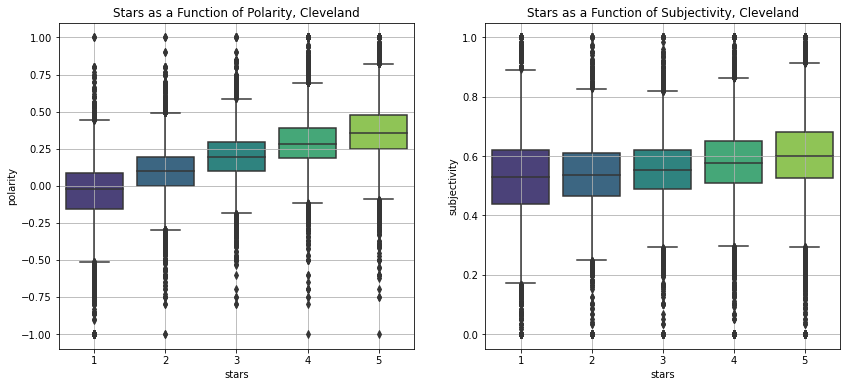

```python
# Initialize the figure and axes
fig, ax = plt.subplots(ncols=2,figsize=(14, 6))

# plotting the box
sns.boxplot(data=review_data,
            x="stars",
            y="polarity",
            ax=ax[0],
            palette="viridis")

sns.boxplot(data=review_data,
            x="stars",
            y="subjectivity",
            ax=ax[1],
            palette="viridis")

# Format with matplotlib commands
ax[0].set_title("Stars as a Function of Polarity, Cleveland")
ax[1].set_title("Stars as a Function of Subjectivity, Cleveland")
ax[1].grid(True)
ax[0].grid(True)
plt.show()
```

**What do the charts indicate for the effectiveness of our sentiment analysis?**

1. In short, the charts indicate that sentiment analysis of reviews works pretty good.
2. The polarity of reviews and the stars have a positive relationship, so reviews with more stars tend to have a greater polarity value. And it can be a good predictor of stars.
3. The subjectivity of reviews and stars don't have such strong relationship, but according to the figure, more stars of a review usually means more subjectivity.
4. There are a lot of outliers in both figures, indecates the possibility that some emotions are not being interpreted effectively from the words.

### 1.6 Individual words

#### 1.6.1 Select a random sample of the review data

Select 1,000 random rows from the DataFrame holding the review data. Use the `.sample()` function to perform the selection.

```python
review_subset = review_data.sample(1000)
```

#### 1.6.2 Re-format the data

```python
def reshape_data(review_subset):
    """
    Reshape the input dataframe of review data.
    """
    from pandas import Series, merge

    X = (review_subset['formatted_text']
         .apply(Series)
         .stack()
         .reset_index(level=1, drop=True)
         .to_frame('word'))


    R = review_subset[['polarity', 'stars', 'review_id']]

    return merge(R, X, left_index=True, right_index=True).reset_index(drop=True)
```

```python
review_subset = reshape_data(review_subset)
review_subset.head()
```

|  | polarity | stars | review_id | word |
| --- | --- | --- | --- | --- |
| 0 | 0.375 | 4 | RMs2QdZN1WvNAU2ZjwsyzQ | love |
| 1 | 0.375 | 4 | RMs2QdZN1WvNAU2ZjwsyzQ | wings |
| 2 | 0.375 | 4 | RMs2QdZN1WvNAU2ZjwsyzQ | love |
| 3 | 0.375 | 4 | RMs2QdZN1WvNAU2ZjwsyzQ | selection |
| 4 | 0.375 | 4 | RMs2QdZN1WvNAU2ZjwsyzQ | beer |

#### 1.6.3 Calculate the average number of stars and polarity for each word

Using the result from 1.6.2, group by the "word" column, and calculate the following three quantities:

1. the size of each group
2. the average number of user stars for each word
3. the average polarity for each word

```python
# group by word and aggregate
review_by_word = (review_subset
                  .groupby("word")
                  .agg({"word":"count",
                        "polarity":"mean",
                        "stars":"mean"})
                  .rename({"word":"word_count"},axis=1))
```

```python
# show the words
review_by_word
```

| word | word_count | polarity | stars |
| --- | --- | --- | --- |
| 0 | 1 | 0.255556 | 1.000000 |
| 1 | 27 | 0.128027 | 2.703704 |
| 10 | 61 | 0.140511 | 2.901639 |
| 100 | 6 | 0.330800 | 4.333333 |
| 1000 | 4 | 0.216482 | 2.750000 |
| ... | ... | ... | ... |
| 味道很不错 | 1 | 0.750000 | 5.000000 |
| 大肉面 | 1 | 0.137560 | 4.000000 |
| 夫妻肺片 | 1 | 0.068275 | 5.000000 |
| 水煮鱼鱼香茄子回锅肉和炒包菜都很赞 | 1 | 0.750000 | 5.000000 |
| 蚂蚁上树 | 1 | 0.068275 | 5.000000 |

8206 rows × 3 columns

#### 1.6.4 Select words the occur at least 50 times in reviews

```python
# select word_count >=50
review_by_word_top50 = review_by_word[review_by_word["word_count"]>=50]

# sort the df by word_count
review_by_word_top50 = review_by_word_top50.sort_values("word_count",ascending=False)
```

```python
review_by_word_top50
```

| word | word_count | polarity | stars |
| --- | --- | --- | --- |
| food | 752 | 0.219582 | 3.500000 |
| good | 581 | 0.265742 | 3.697074 |
| place | 548 | 0.216916 | 3.600365 |
| great | 516 | 0.335279 | 4.112403 |
| service | 352 | 0.226461 | 3.517045 |
| ... | ... | ... | ... |
| maybe | 50 | 0.169211 | 3.060000 |
| tacos | 50 | 0.237356 | 3.660000 |
| without | 50 | 0.202053 | 3.840000 |
| top | 50 | 0.302895 | 4.380000 |
| patio | 50 | 0.284363 | 4.220000 |

222 rows × 3 columns

#### 1.6.5 Plot the average polarity vs user stars

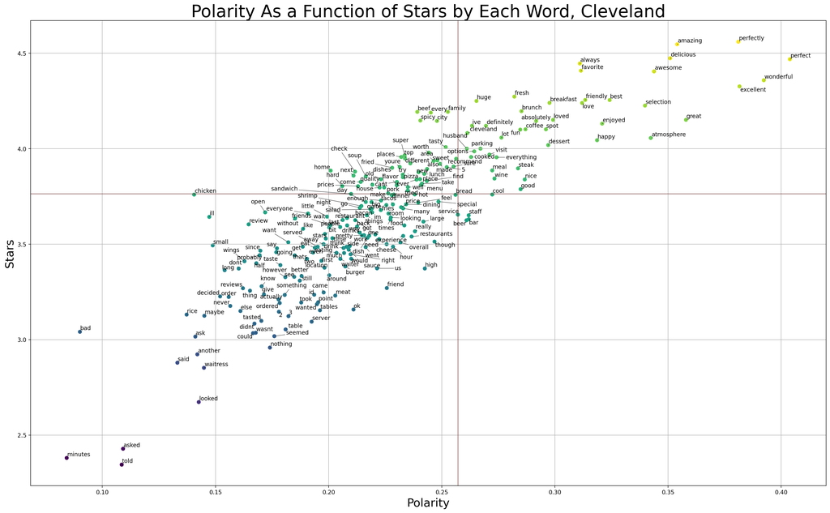

```python
# Initialize the figure and axes
fig, ax = plt.subplots(figsize=(25, 15),dpi=200)

# plotting the avg value lines
brown = "#6d2d2d88"
plt.axvline(review_data["polarity"].mean(),c=brown)
plt.axhline(review_data["stars"].mean(),c=brown)

# plotting the points
plt.scatter(data=review_by_word_top50,
            x="polarity",
            y="stars",c="stars")

# plotting the text
for word, row in review_by_word_top50.iterrows():
    t = plt.text(row["polarity"],row["stars"],word,)

# Format with matplotlib commands
plt.title("Polarity As a Function of Stars by Each Word, Cleveland",fontdict={"fontsize":30})
plt.xlabel("Polarity",fontdict={"fontsize":20})
plt.ylabel("Stars",fontdict={"fontsize":20})
plt.grid(True)
plt.show()
```

**The figure above shows that there is a positive liner relationship between Polarity and Stars of words. Low polarity words like bad, minutes (indicates long waiting time) have lower stars. While reviews with perfect, wonderful or great often have more stars.**

## 2. Correlating restaurant data and household income

In this part, I'll use the census API to download household income data and overlay restaurant locations.

### 2.1 Query the Census API

`cenpy` package is used to download **median household income in the past 12 months** by census tract from the 2018 ACS 5-year data set for your county of interest.

```python
import cenpy
```

```python
acs18 = cenpy.products.ACS(2018).from_county("Cuyahoga, OH", level='tract',
                                        variables=['B19013_001E', 'B001001_001E']) # median household income
```

```python
# rename var
acs18 = acs18.rename({"B19013_001E":"MedianHHInc",},axis=1)
acs18
```

|  | GEOID | geometry | MedianHHInc | NAME | state | county | tract |
| --- | --- | --- | --- | --- | --- | --- | --- |
| 0 | 39035174203 | POLYGON ((-9124910.310 5069748.250, -9124910.3... | 73954.0 | Census Tract 1742.03, Cuyahoga County, Ohio | 39 | 035 | 174203 |
| 1 | 39035174103 | POLYGON ((-9124910.310 5071122.170, -9124910.3... | 61384.0 | Census Tract 1741.03, Cuyahoga County, Ohio | 39 | 035 | 174103 |
| 2 | 39035189111 | POLYGON ((-9124843.410 5076183.570, -9124843.4... | 85192.0 | Census Tract 1891.11, Cuyahoga County, Ohio | 39 | 035 | 189111 |
| 3 | 39035174204 | POLYGON ((-9121971.030 5070569.700, -9121969.8... | 75208.0 | Census Tract 1742.04, Cuyahoga County, Ohio | 39 | 035 | 174204 |
| 4 | 39035190504 | POLYGON ((-9124987.790 5064558.090, -9124976.8... | 86226.0 | Census Tract 1905.04, Cuyahoga County, Ohio | 39 | 035 | 190504 |
| ... | ... | ... | ... | ... | ... | ... | ... |
| 442 | 39035170101 | POLYGON ((-9073343.010 5090670.400, -9073343.0... | 63879.0 | Census Tract 1701.01, Cuyahoga County, Ohio | 39 | 035 | 170101 |
| 443 | 39035195600 | POLYGON ((-9074103.990 5070760.830, -9073947.3... | 57719.0 | Census Tract 1956, Cuyahoga County, Ohio | 39 | 035 | 195600 |
| 444 | 39035131104 | POLYGON ((-9072292.150 5086561.820, -9072073.9... | 70978.0 | Census Tract 1311.04, Cuyahoga County, Ohio | 39 | 035 | 131104 |
| 445 | 39035172202 | POLYGON ((-9069409.640 5086935.500, -9069357.1... | 54595.0 | Census Tract 1722.02, Cuyahoga County, Ohio | 39 | 035 | 172202 |
| 446 | 39035184108 | POLYGON ((-9065858.330 5064025.570, -9065845.8... | 113672.0 | Census Tract 1841.08, Cuyahoga County, Ohio | 39 | 035 | 184108 |

447 rows × 7 columns

### 2.2 Download census tracts from the Census and merge the data from Part 2.1

```python
# Already done that in 2.1
acs18
```

|  | GEOID | geometry | MedianHHInc | NAME | state | county | tract |
| --- | --- | --- | --- | --- | --- | --- | --- |
| 0 | 39035174203 | POLYGON ((-9124910.310 5069748.250, -9124910.3... | 73954.0 | Census Tract 1742.03, Cuyahoga County, Ohio | 39 | 035 | 174203 |
| 1 | 39035174103 | POLYGON ((-9124910.310 5071122.170, -9124910.3... | 61384.0 | Census Tract 1741.03, Cuyahoga County, Ohio | 39 | 035 | 174103 |
| 2 | 39035189111 | POLYGON ((-9124843.410 5076183.570, -9124843.4... | 85192.0 | Census Tract 1891.11, Cuyahoga County, Ohio | 39 | 035 | 189111 |
| 3 | 39035174204 | POLYGON ((-9121971.030 5070569.700, -9121969.8... | 75208.0 | Census Tract 1742.04, Cuyahoga County, Ohio | 39 | 035 | 174204 |
| 4 | 39035190504 | POLYGON ((-9124987.790 5064558.090, -9124976.8... | 86226.0 | Census Tract 1905.04, Cuyahoga County, Ohio | 39 | 035 | 190504 |
| ... | ... | ... | ... | ... | ... | ... | ... |
| 442 | 39035170101 | POLYGON ((-9073343.010 5090670.400, -9073343.0... | 63879.0 | Census Tract 1701.01, Cuyahoga County, Ohio | 39 | 035 | 170101 |
| 443 | 39035195600 | POLYGON ((-9074103.990 5070760.830, -9073947.3... | 57719.0 | Census Tract 1956, Cuyahoga County, Ohio | 39 | 035 | 195600 |
| 444 | 39035131104 | POLYGON ((-9072292.150 5086561.820, -9072073.9... | 70978.0 | Census Tract 1311.04, Cuyahoga County, Ohio | 39 | 035 | 131104 |
| 445 | 39035172202 | POLYGON ((-9069409.640 5086935.500, -9069357.1... | 54595.0 | Census Tract 1722.02, Cuyahoga County, Ohio | 39 | 035 | 172202 |
| 446 | 39035184108 | POLYGON ((-9065858.330 5064025.570, -9065845.8... | 113672.0 | Census Tract 1841.08, Cuyahoga County, Ohio | 39 | 035 | 184108 |

447 rows × 7 columns

### 2.3 Plot a choropleth map of the household income

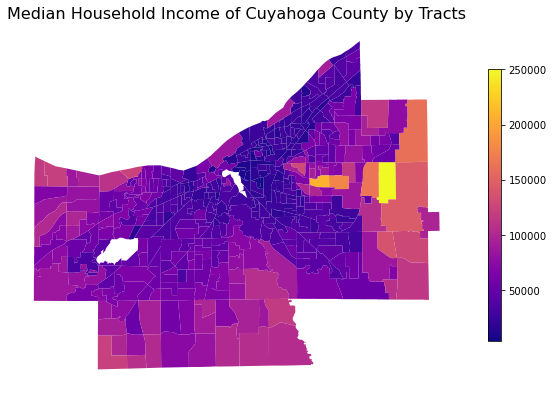

```python
#using crs EPSG:6548 - NAD83(2011) / Ohio North
acs18 = acs18.to_crs(6548)

f,ax = plt.subplots(figsize=(10,10))

# Plot the choropleth
acs18.plot("MedianHHInc",ax=ax,cmap='plasma', legend=True,
           legend_kwds={"shrink":0.5})

# Format
ax.set_title("Median Household Income of Cuyahoga County by Tracts", fontsize=16)
ax.set_axis_off()

plt.show()
```

### 2.4 Load the restaurants data

```python
import geopandas as gpd
```

```python
# reading file
restaurants = pd.read_json("./data/restaurants_cleveland.json.gz",orient='records',lines=True)
```

```python
# making points
restaurants_pt = gpd.points_from_xy(restaurants.longitude,restaurants.latitude,crs=4326)
```

```python
# making it geo df
restaurants_geom = gpd.GeoDataFrame(restaurants,geometry=restaurants_pt).to_crs(6548)
```

### 2.5 Overlay restaurants on the income map

Overlay the restaurants and color the points according to the 'stars' column.

```python
# using the restaurants boundary
[xmin, ymin, xmax, ymax] = restaurants_geom.geometry.total_bounds
```

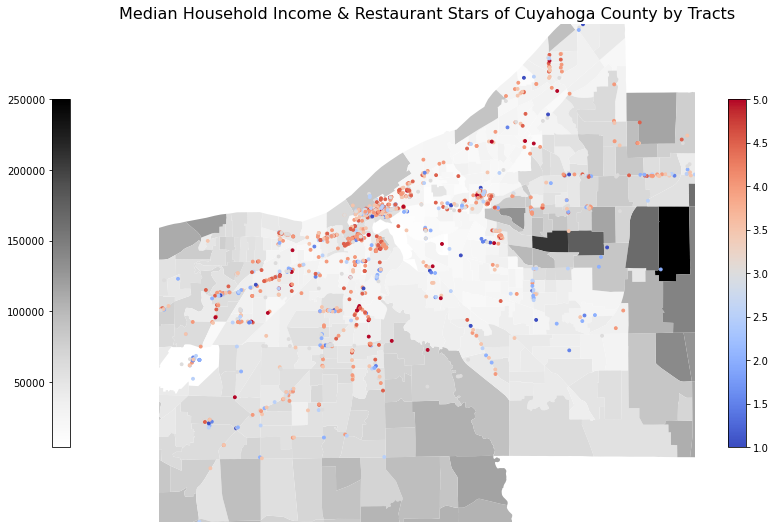

```python
f,ax = plt.subplots(figsize=(16,16))

# Plot the choropleth
acs18.plot("MedianHHInc",ax=ax,cmap='Greys', legend=True,
           legend_kwds={"shrink":0.4,"location":"left"})

# Plot the restaurants
restaurants_geom.plot("stars",ax=ax,cmap='coolwarm', legend=True,
                     legend_kwds={"shrink":0.4},markersize=8)

# Format
ax.set_title("Median Household Income & Restaurant Stars of Cuyahoga County by Tracts", fontsize=16)
ax.set_axis_off()
ax.set_xlim(xmin, xmax)
ax.set_ylim(ymin, ymax)

plt.show()
```

**There is no clear relationship between medium house income and stars**

### 2.6 Comparing polarity vs. stars geographically

```python
review_geom = restaurants_geom.merge(review_data,on="business_id",how="left")
```

```python
review_geom
```

|  | business_id | latitude | longitude | name | review_count | stars_x | geometry | review_id | stars_y | text | formatted_text | polarity | subjectivity |
| --- | --- | --- | --- | --- | --- | --- | --- | --- | --- | --- | --- | --- | --- |
| 0 | OwXMxqxIy4YoprAjnoUoiA | 41.540890 | -81.595327 | B & M Bar-B-Que Shaw | 4 | 3.5 | POINT (675485.852 208520.362) | pRfdZnKT73hNV-cUWYGVAA | 4 | OMFG!!!!\nbeen a fan my whole life... I moved ... | [omfg, fan, whole, life, moved, kentucky, drov... | 0.500000 | 0.575000 |
| 1 | OwXMxqxIy4YoprAjnoUoiA | 41.540890 | -81.595327 | B & M Bar-B-Que Shaw | 4 | 3.5 | POINT (675485.852 208520.362) | F0h8Uc1G87vbUl1rgKLrSg | 3 | I like a sense of adventure so I went to the p... | [like, sense, adventure, went, place, bullet, ... | 0.385714 | 0.364286 |
| 2 | OwXMxqxIy4YoprAjnoUoiA | 41.540890 | -81.595327 | B & M Bar-B-Que Shaw | 4 | 3.5 | POINT (675485.852 208520.362) | JEe8kchmQ3WiC1KRZhi1mg | 4 | Night or day the men are the best from, the ta... | [night, day, men, best, tall, light, skinned, ... | 0.203704 | 0.429630 |
| 3 | OwXMxqxIy4YoprAjnoUoiA | 41.540890 | -81.595327 | B & M Bar-B-Que Shaw | 4 | 3.5 | POINT (675485.852 208520.362) | EYUregGwl02AMnlA2G2dyQ | 3 | Always have loved this spot e.105 location suc... | [always, loved, spot, e105, location, sucked, ... | 0.080000 | 0.480000 |
| 4 | 3e0IGa_-zqTemKLc1dbdmg | 41.510985 | -81.603050 | Phusion Cafe | 17 | 3.5 | POINT (674875.622 205192.595) | RixckAK2JzzZ4YZsCxQh3A | 1 | The b7 I ordered looks/tastes nothing like nig... | [b7, ordered, lookstastes, nothing, like, nigh... | -0.600000 | 0.950000 |
| ... | ... | ... | ... | ... | ... | ... | ... | ... | ... | ... | ... | ... | ... |
| 82694 | soQEl35sQuARBOlH1Y6MaQ | 41.519727 | -81.462937 | Teresa's Pizza | 19 | 3.5 | POINT (686559.903 206293.046) | fyjBLPAWgEZj6ru3JYumGw | 2 | Very disappointing. Sweet, thin sauce - normal... | [disappointing, sweet, thin, sauce, normally, ... | 0.001190 | 0.623214 |
| 82695 | soQEl35sQuARBOlH1Y6MaQ | 41.519727 | -81.462937 | Teresa's Pizza | 19 | 3.5 | POINT (686559.903 206293.046) | CRiZJNp8qMnJWUiZd1n2QQ | 5 | If you have never eaten Teresa's Pizza, you ar... | [never, eaten, teresas, pizza, missing, one, g... | 0.400000 | 0.525000 |
| 82696 | Ylm9cM4xIFgg6LLBr8Euow | 41.392982 | -81.758133 | Cuisine Express At Valero | 3 | 3.5 | POINT (662041.434 191966.223) | CdalwIZWiTJkDvueKt1xmA | 5 | My boyfriend and I have been regulars here sin... | [boyfriend, regulars, since, leasing, manager,... | 0.586111 | 0.505556 |
| 82697 | Ylm9cM4xIFgg6LLBr8Euow | 41.392982 | -81.758133 | Cuisine Express At Valero | 3 | 3.5 | POINT (662041.434 191966.223) | lDFjnP5fvkemYpwE_gg4zQ | 2 | Hit or miss. I guess it depends on whose worki... | [hit, miss, guess, depends, whose, working, al... | 0.000000 | 0.000000 |
| 82698 | Ylm9cM4xIFgg6LLBr8Euow | 41.392982 | -81.758133 | Cuisine Express At Valero | 3 | 3.5 | POINT (662041.434 191966.223) | RLIX-qe7Y0VFUHU7o6yRSA | 4 | Never thought I'd review a sandwich counter at... | [never, thought, id, review, sandwich, counter... | 0.444048 | 0.738095 |

82699 rows × 13 columns

[figure not shown]

```python
f,ax = plt.subplots(ncols=2,figsize=(20,8))

# get the variables
x = review_geom.geometry.x
y = review_geom.geometry.y
stars = review_geom.stars_y
polarity = review_geom.polarity
gridsize=30

# plot the background color
ax[0].hexbin(x, y,gridsize=gridsize,mincnt=0)
ax[1].hexbin(x, y,gridsize=gridsize,mincnt=0)

# plot the hexbins
ax[0].hexbin(x, y, stars,gridsize=gridsize,bins=8)
ax[1].hexbin(x, y, polarity,gridsize=gridsize, bins=8)

# overlay the acs tracts
acs18.plot(ax=ax[0], facecolor='none', linewidth=0.3, edgecolor='white')
acs18.plot(ax=ax[1], facecolor='none', linewidth=0.3, edgecolor='white')

# Format
for a in ax:
    a.set_axis_off()
    a.set_xlim(xmin, xmax)
    a.set_ylim(ymin, ymax)
ax[0].set_title("Review Polarity Hexbin Map", fontsize=16)
ax[1].set_title("Review Stars Hexbin Map", fontsize=16)
f.suptitle("Review polarity vs. stars geographically", fontsize=22)
plt.show()
```

**As is mentioned before, there is a positive relationship between review polarity and stars, and according to the figure above, the geographical relationship also exists.**